# Example using LM3-PPA

## Example

### Simulation settings

Manually select some sites from which we’re going to use the data for evaluation and calibration.

Create a site meta info table that contains all the site-specific information that is used to force site-simulations (e.g. starting year, number of simulations years, elevation, etc.). For FLUXNET2015 data, required meta info is provided by the `rsofun` package (data frame `rsofun::metainfo_Tier1_sites_kgclimate_fluxnet2015`).

```r
# Take only year 2004 to 2014, corresponding to subset of data for site CH-Lae
siteinfo <- data.frame(
  sitename="CH-Lae",
  lon = 8.365,
  lat = 47.47808,
  elv = 700,
  year_start = 2004,
  year_end = 2014,
  classid = NA,
  c4 = FALSE,
  whc = NA,
  koeppen_code = NA,
  igbp_land_use = "Mixed Forests",
  plant_functional_type = "Broadleaf trees"
  )

siteinfo <- as_tibble(siteinfo)
siteinfo <- siteinfo %>%
  dplyr::mutate(date_start = lubridate::ymd(paste0(year_start, "-01-01"))) %>%
  dplyr::mutate(date_end = lubridate::ymd(paste0(year_end, "-12-31")))
```

Now specify the simulation parameters that are identical for all site-scale simulations.

```r
params_siml <- tibble( #list
      spinup                = TRUE,
      spinupyears           = 700,
      recycle               = 800,    # 9 or 11 changed to 1 when aggregating forcing into 1 year
      firstyeartrend        = 2009,
      nyeartrend            = 800,    # 9 or 11 (longer transient years)
      outputhourly          = TRUE,
      outputdaily           = TRUE,
      do_U_shaped_mortality = TRUE,
      update_annualLAImax   = TRUE,
      do_closedN_run        = TRUE,
      method_photosynth     = "gs_leuning", # gs_leuning or pmodel
      method_mortality      = "dbh" # dbh or cstarvation or growthrate or const_selfthing
      )
```

#### Photosynthesis method

The model includes two methods for estimating NPP: (a) “gs_leuning” the original method described for the LM3-PPA (Weng et al. 2015). (b) “pmodel” the implementation of the P-model (Stocker et al. 2020) within the LM3-PPA. The P-model which simulates acclimated photosynthetic parameters and light use efficiency for daily time steps. For the implementation of the P-model in LM3-PPA, GPP is calculated at the cohort-level (not canopy-level), using light absorbed per cohort, and expressed in kg C per day and per tree (or cohort). PAR is the amount of light reaching the respective layer (mol m-2 s-1). fAPAR is attenuated based on the leaf area index within-crown of all layers above and on a fixed exponential light extinction (with k=0.75). LUE is simulated as gpp per unit absorbed light (g C mol−1) and depends on a fix quantum yield efficiency parameter. (kphio Long et al., 1993).

#### Mortality method

The model allows for four different mortality functional forms: (a) “dbh” as a function of size: high mortality rate for large trees (following Weng et al. 2015). (b) “cstarvation” as a function of tree’s C balance: carbon starvation as a decreasing in the cohort’s NSC level. (c) “growthrate” as a function of growth rate: high mortality rate for faster growing trees. (d) “const_selfthin” as a constant self-thinning relationship.

### Define model parameters

#### Soil parameters

By layers.

#### Initial cohort specification

Select the species identity of the initial cohorts and initial biomass. With `init_cohort_species = rep(2, 10)` we’re selecting ten cohorts of the same species (number 2 or number 1).

### Define soil parameters

For now, this is implemented as an illustration. Should be made site-specific.

### Get input

Changing values of radiation for running simulations

Collect all drivers

```r
print(packageVersion("rsofun"))
```

```
## [1] '4.1'
```

```r
if(packageVersion("rsofun") == "4.0"){
df_drivers <- tibble(sitename,
                    siteinfo = list(tibble(siteinfo)),
                    params_siml = list(tibble(params_siml)),
                    params_tile = list(tibble(params_tile)),
                    params_species=list(tibble(params_species)),
                    params_soil=list(tibble(params_soil)),
                    init_cohort=list(tibble(init_cohort)),
                    init_soil=list(tibble(init_soil)),
                    forcing=list(tibble(forcing)),
                    .name_repair = "unique")
} else {
  df_drivers <- tibble(sitename,
                    site_info = list(tibble(siteinfo)),
                    params_siml = list(tibble(params_siml)),
                    params_tile = list(tibble(params_tile)),
                    params_species=list(tibble(params_species)),
                    params_soil=list(tibble(params_soil)),
                    init_cohort=list(tibble(init_cohort)),
                    init_soil=list(tibble(init_soil)),
                    forcing=list(tibble(forcing)),
                    .name_repair = "unique")
}
```

### Run the model

Run the model for all the sites specified in the first step.

```r
out <- run_lm3ppa_f_bysite( sitename,
                            params_siml,
                            siteinfo,
                            forcing, # ddf_input
                            params_tile,
                            params_species,
                            params_soil,
                            init_cohort,
                            init_soil,
                            makecheck = TRUE)

out$output_annual_tile %>%
  ggplot() +
  geom_line(aes(x = year, y = GPP)) +
  theme_classic()+labs(x = "Year", y = "GPP")

out$output_annual_tile %>%
  ggplot() +
  geom_line(aes(x = year, y = plantC)) +
  theme_classic()+labs(x = "Year", y = "plantC")
```

[output not shown]

Run for the full set of sites

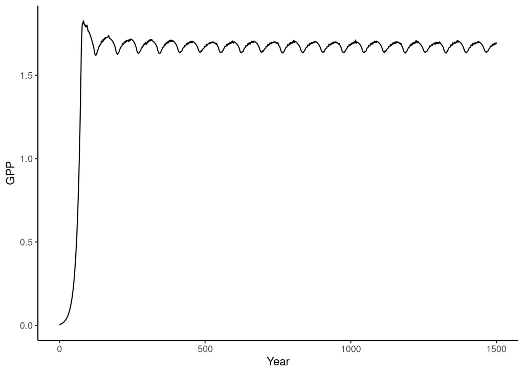

```r
df_output <- runread_lm3ppa_f(
     df_drivers,
     makecheck = TRUE,
     parallel = FALSE
     )

df_output$data[[1]]$output_annual_tile %>%
  ggplot() +
  geom_line(aes(x = year, y = GPP)) +
  theme_classic()+labs(x = "Year", y = "GPP")
```

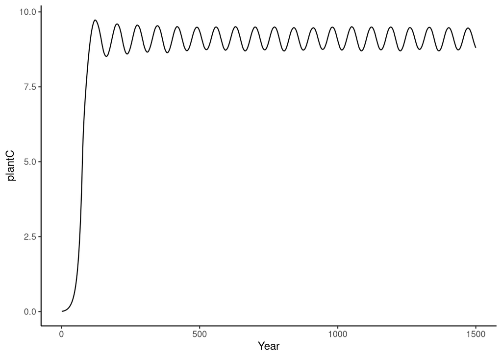

```r
df_output$data[[1]]$output_annual_tile %>%
  ggplot() +
  geom_line(aes(x = year, y = plantC)) +
  theme_classic()+labs(x = "Year", y = "plantC")
```